# SunPy Overview

Email: steven.christe@nasa.gov

This presentation was first shown at the [13th RHESSI Workshop](http://sprg.ssl.berkeley.edu/~solarsdy/rhessi13/)

## What is SunPy?

### A community-developed, free and open-source solar data analysis environment for Python.

website: http://www.sunpy.org  
docs: http://docs.sunpy.org  
code (version control!): https://github.com/sunpy/sunpy

SunPy is built upon foundational libraries which enable scientific computing in Python which includes

- [NumPy](http://numpy.org)
- [SciPy](http://scipy.org)
- [matplotlib](http://matplotlib.org)

and also (increasingly)

- [Astropy](http://astropy.org)

Setting up the notebook for inline plots

```python
%matplotlib inline
import warnings
warnings.filterwarnings('ignore')
```

```python
import numpy as np
```

```python
import matplotlib.pyplot as plt
```

```python
import sunpy
```

```python
sunpy.system_info()
```

```
==========================================================
 SunPy Installation Information

==========================================================

###########
 General
###########
Time : Friday, 31. July 2015 08:53PM UT
System : Darwin
Processor : i386
Arch : 64bit
SunPy : 0.7.dev6038
SunPy_git : a05bba64aae24ed8e520f11915d86baa0f6f81ca
OS: Mac OS X 10.10.3 (i386)


###########
 Required Libraries
###########
Python: 2.7.10
NumPy: 1.9.2
SciPy: 0.15.1
matplotlib: 1.4.3
Astropy: 1.0.1
Pandas: 0.16.1


###########
 Recommended Libraries
###########
beautifulsoup: 4.3.2
PyQt: 4.11.3
SUDS: 0.4
Sqlalchemy: 0.9.4
Requests: 2.7.0
```

# 1. Solar Images in SunPy

SunPy has a `Map` type that supports 2D images, it makes it simple to read data in from any filetype supported in `sunpy.io` which is currently FITS, JPEG2000 and ANA files. You can also create maps from any `(data, metadata)` pair.

SunPy provides a few test data files which you can download by following [these instructions](http://docs.sunpy.org/en/stable/guide/acquiring_data/sample-data.html#sample-data). Shortcuts are

- `sunpy.data.sample.AIA_171_IMAGE`
- `sunpy.data.sample.CALLISTO_IMAGE`
- `sunpy.data.sample.EIT_195_IMAGE`
- `sunpy.data.sample.RHESSI_EVENT_LIST`
- `sunpy.data.sample.RHESSI_IMAGE`

These are all just links to FITS files contained in the SunPy distribution.

```python
import sunpy.data.sample
print sunpy.data.sample.AIA_171_IMAGE
```

```
/Users/ainglis/sunpy/data/sample_data/AIA20110319_105400_0171.fits
```

```python
import sunpy.map

aiamap = sunpy.map.Map(sunpy.data.sample.AIA_171_IMAGE)
aiamap
```

```
SunPy AIAMap
---------
Observatory:	 SDO
Instrument:	 AIA 3
Detector:	 AIA
Measurement:	 171.0 Angstrom
Wavelength:	 171.0 Angstrom
Obs Date:	 2011-03-19 10:54:00
dt:		 1.999601 s
Dimension:	 [ 1024.  1024.] pix
scale:		 [ 2.4  2.4] arcsec / pix

array([[ 0.3125, -0.0625, -0.125 , ...,  0.625 , -0.625 ,  0.    ],
       [ 1.    ,  0.1875, -0.8125, ...,  0.625 , -0.625 ,  0.    ],
       [-1.1875,  0.375 , -0.5   , ..., -0.125 , -0.625 , -1.1875],
       ...,
       [-0.625 ,  0.0625, -0.3125, ...,  0.125 ,  0.125 ,  0.125 ],
       [ 0.5625,  0.0625,  0.5625, ..., -0.0625, -0.0625,  0.    ],
       [ 0.5   , -0.125 ,  0.4375, ...,  0.6875,  0.6875,  0.6875]])
```

Maps contain both the image data and the metadata associated with the image, this metadata currently does not deviate much from the standard FITS WCS keywords, but presented in a instrument-independant manner.

[Documentation on the Map Object](http://docs.sunpy.org/en/stable/api/sunpy.map.mapbase.GenericMap.html#sunpy.map.mapbase.GenericMap)

The data (stored in a numpy array)

```python
aiamap.data
```

```
array([[ 0.3125, -0.0625, -0.125 , ...,  0.625 , -0.625 ,  0.    ],
       [ 1.    ,  0.1875, -0.8125, ...,  0.625 , -0.625 ,  0.    ],
       [-1.1875,  0.375 , -0.5   , ..., -0.125 , -0.625 , -1.1875],
       ...,
       [-0.625 ,  0.0625, -0.3125, ...,  0.125 ,  0.125 ,  0.125 ],
       [ 0.5625,  0.0625,  0.5625, ..., -0.0625, -0.0625,  0.    ],
       [ 0.5   , -0.125 ,  0.4375, ...,  0.6875,  0.6875,  0.6875]])
```

```python
aiamap.data.max()
```

```
9429.125
```

The standard deviation

```python
aiamap.data.std()
```

```
292.43424704677756
```

```python
aiamap.data.min()
```

```
-2.0
```

The original metadata (stored in a dictionary)

```python
aiamap.meta
```

```
MapMeta([('dsun_obs', 148940609626.98), ('t_obs', '2011-03-19T10:54:01.34Z'), ('tobsepoc', '1977.01.01_00:00:00_TAI'), ('simple', True), ('datavals', 16777216), ('aimgshen', 4), ('aimshctc', 2054.875977), ('aiftsid', 40960), ('comment', "FITS (Flexible Image Transport System) format is defined in 'A…
```

```python
aiamap.meta.keys()
```

```
['dsun_obs',
 't_obs',
 'tobsepoc',
 'simple',
 'datavals',
 'aimgshen',
 'aimshctc',
 'aiftsid',
 'comment',
 'aihis348',
 'roi_llx2',
 'extend',
 'aivnmst',
 'aicfgdl4',
 'crlt_obs',
 'aicfgdl1',
 'aicfgdl2',
 'aicfgdl3',
 'totvals',
 'acs_mode',
 'crota2',
 'aimshobe',
 'aimshobc',
 'aihis860',
 'r_sun',
 'orb_rec',
 'fid',
 'wave_str',
 'aecdelay',
 'int_time',
 'aimshcbc',
 'sat_z0',
 'lvl_num',
 'acs_safe',
 'aimshcbe',
 'aifoenfl',
 'aifdbid',
 'aimgots',
 'ctype1',
 'exptime',
```

[output cut: 117 more lines]

```
 'flat_rec',
 'bzero',
 'roi_lly2',
 'x0_mp',
 'roi_lly1',
 'aiagp4',
 'y0_lf',
 'agt2svy',
 'recnum',
 'agt2svz',
 'aiagp10',
 'bscale',
 'aectype',
 'sat_y0',
 'detector']
```

```python
aiamap.meta.get('rsun_obs')
```

```
963.879683
```

We also provide quick access to some key metadata values as object variables

```python
print(aiamap.date, aiamap.coordinate_system, aiamap.detector, aiamap.dsun)
```

```
(datetime.datetime(2011, 3, 19, 10, 54, 0, 340000), Pair(x='HPLN-TAN', y='HPLT-TAN'), 'AIA', <Quantity 148940609626.98 m>)
```

The properties of the map provide a standard way of reading meta data. For instance the pixel scale can be accessed with the `.scale` attribute:

```python
aiamap.scale
```

```
Pair(x=<Quantity 2.4 arcsec / pix>, y=<Quantity 2.4 arcsec / pix>)
```

```python
aiamap.yrange
```

$[-1228.8,~1228.8] \; \mathrm{{}^{\prime\prime}}$

```python
aiamap.xrange
```

$[-1228.8,~1228.8] \; \mathrm{{}^{\prime\prime}}$

Map provides some useful functions such as

- submap
- plotting
- resampling

## Playing with a map

```python
import astropy.units as u
aiasub = aiamap.submap([-250,50]*u.arcsec,[-550,-250]*u.arcsec)
```

```python
aiasub.xrange, aiasub.yrange
```

```
(<Quantity [-249.6,  50.4] arcsec>, <Quantity [-549.6,-249.6] arcsec>)
```

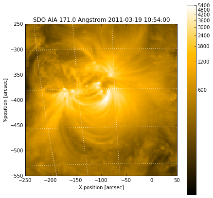

```python
fig, ax = plt.subplots(1, figsize=(7,7))
im = aiasub.plot(axes=ax, vmin=100, vmax=aiasub.data.max())
ax = aiasub.draw_grid(grid_spacing=5*u.deg)
cbar = plt.colorbar()
```

## Composite Maps

Composite maps inherits from genericMap and can handle multiple maps and lets you plot them together.

```python
compmap = sunpy.map.Map(sunpy.data.sample.AIA_171_IMAGE, sunpy.data.sample.RHESSI_IMAGE, composite=True)
```

```python
levels = np.arange(0,50,5)
print(levels)
compmap.set_levels(1, levels, percent=True)
compmap.set_alpha(1,0.5)
compmap.set_colors(1, 'Reds_r')
```

```
[ 0  5 10 15 20 25 30 35 40 45]
```

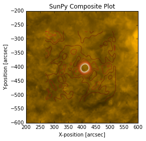

```python
ax = plt.subplot()
compmap.plot()
ax.axis([200, 600, -600, -200])
plt.show()
```

## Spectrograms

```python
from sunpy.spectra.sources.callisto import CallistoSpectrogram
callisto = CallistoSpectrogram.read(sunpy.data.sample.CALLISTO_IMAGE)
```

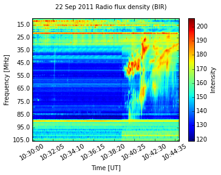

```python
callisto.peek(vmin = 0)
```

```python
callisto_nobg = callisto.subtract_bg()
```

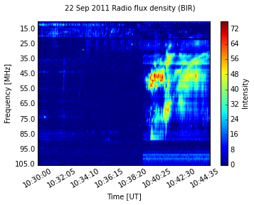

```python
callisto_nobg.peek(vmin = 0)
```

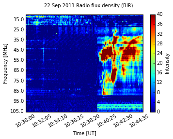

```python
callisto_nobg.peek(vmin = 0, vmax = 40)
```

```python
callisto.data
```

```
array([[147, 153, 149, ..., 158, 157, 157],
       [152, 156, 152, ..., 162, 162, 158],
       [155, 156, 155, ..., 162, 163, 162],
       ...,
       [153, 153, 154, ..., 147, 147, 148],
       [137, 137, 138, ..., 145, 145, 145],
       [140, 141, 144, ..., 147, 146, 146]], dtype=uint8)
```

## Lightcurves

```python
import sunpy.lightcurve
evelc = sunpy.lightcurve.EVELightCurve.create('2014/01/01')
```

```python
evelc.data
```

| HHMM | XRS-B proxy | XRS-A proxy | SEM proxy | 0.1-7ESPquad | 17.1ESP | 25.7ESP | 30.4ESP | 36.6ESP | darkESP | 121.6MEGS-P | darkMEGS-P | q0ESP | q1ESP | q2ESP | q3ESP | CMLat | CMLon | x_cool proxy | oldXRSB proxy |
| --- | --- | --- | --- | --- | --- | --- | --- | --- | --- | --- | --- | --- | --- | --- | --- | --- | --- | --- | --- |
| 2014-01-01 00:00:00 | 0.000006 | 4.030000e-07 | 0.000858 | 0.00196 | 0.000904 | 0.000547 | 0.000958 | NaN | 49.4 | NaN | 39.2 | 0.334 | 0.157 | 0.351 | 0.158 | -28.9 | -0.9 | 2320 | 0.000005 |
| 2014-01-01 00:01:00 | 0.000006 | 4.010000e-07 | 0.000858 | 0.00195 | 0.000904 | 0.000547 | 0.000959 | NaN | 49.4 | NaN | 39.2 | 0.334 | 0.157 | 0.351 | 0.158 | -28.8 | -0.9 | 2320 | 0.000005 |
| 2014-01-01 00:02:00 | 0.000006 | 4.020000e-07 | 0.000857 | 0.00195 | 0.000903 | 0.000547 | 0.000957 | NaN | 49.4 | NaN | 39.2 | 0.334 | 0.157 | 0.350 | 0.158 | -28.7 | -1.2 | 2320 | 0.000005 |
| 2014-01-01 00:03:00 | 0.000006 | 3.990000e-07 | 0.000857 | 0.00195 | 0.000903 | 0.000547 | 0.000956 | NaN | 49.4 | NaN | 39.2 | 0.334 | 0.157 | 0.351 | 0.158 | -28.8 | NaN | 2330 | 0.000005 |
| 2014-01-01 00:04:00 | 0.000006 | 3.960000e-07 | 0.000856 | 0.00194 | 0.000903 | 0.000547 | 0.000955 | NaN | 49.4 | NaN | 39.2 | 0.334 | 0.157 | 0.351 | 0.158 | -28.7 | NaN | 2330 | 0.000005 |
| 2014-01-01 00:05:00 | 0.000006 | 3.950000e-07 | 0.000856 | 0.00194 | 0.000903 | 0.000547 | 0.000955 | NaN | 49.5 | NaN | 39.2 | 0.335 | 0.157 | 0.350 | 0.158 | -28.8 | -1.3 | 2330 | 0.000005 |
| 2014-01-01 00:06:00 | 0.000006 | 3.960000e-07 | 0.000856 | 0.00194 | 0.000903 | 0.000546 | 0.000955 | NaN | 49.5 | NaN | 39.2 | 0.334 | 0.158 | 0.351 | 0.158 | -28.8 | -1.3 | 2330 | 0.000005 |
| 2014-01-01 00:07:00 | 0.000006 | 3.970000e-07 | 0.000856 | 0.00194 | 0.000903 | 0.000546 | 0.000955 | NaN | 49.5 | NaN | 39.2 | 0.334 | 0.158 | 0.350 | 0.158 | -28.7 | -1.3 | 2330 | 0.000005 |
| 2014-01-01 00:08:00 | 0.000006 | 4.000000e-07 | 0.000856 | 0.00194 | 0.000903 | 0.000546 | 0.000956 | NaN | 49.5 | NaN | 39.2 | 0.335 | 0.158 | 0.350 | 0.158 | -28.7 | -1.8 | 2330 | 0.000005 |
| 2014-01-01 00:09:00 | 0.000006 | 4.020000e-07 | 0.000857 | 0.00195 | 0.000904 | 0.000546 | 0.000956 | NaN | 49.5 | NaN | 39.2 | 0.335 | 0.158 | 0.349 | 0.158 | -28.7 | -2.0 | 2330 | 0.000005 |
| 2014-01-01 00:10:00 | 0.000006 | 4.050000e-07 | 0.000857 | 0.00196 | 0.000904 | 0.000546 | 0.000956 | NaN | 49.5 | NaN | 39.2 | 0.335 | 0.159 | 0.349 | 0.158 | -28.6 | -2.1 | 2340 | 0.000005 |
| 2014-01-01 00:11:00 | 0.000006 | 4.110000e-07 | 0.000856 | 0.00197 | 0.000903 | 0.000546 | 0.000956 | NaN | 49.5 | NaN | 39.2 | 0.335 | 0.159 | 0.349 | 0.158 | -28.6 | -2.4 | 2340 | 0.000005 |
| 2014-01-01 00:12:00 | 0.000006 | 4.250000e-07 | 0.000856 | 0.00199 | 0.000903 | 0.000546 | 0.000955 | 0.000445 | 49.5 | NaN | 39.2 | 0.336 | 0.159 | 0.348 | 0.157 | -28.6 | -3.0 | 2340 | 0.000005 |
| 2014-01-01 00:13:00 | 0.000006 | 4.480000e-07 | 0.000855 | 0.00203 | 0.000903 | 0.000546 | 0.000954 | 0.007550 | 49.5 | NaN | 39.3 | 0.338 | 0.160 | 0.345 | 0.156 | -28.6 | -4.7 | 2340 | 0.000006 |
| 2014-01-01 00:14:00 | 0.000006 | 4.730000e-07 | 0.000855 | 0.00208 | 0.000903 | 0.000546 | 0.000954 | 0.013800 | 49.5 | NaN | 39.3 | 0.341 | 0.161 | 0.343 | 0.156 | -28.5 | -6.7 | 2340 | 0.000006 |
| 2014-01-01 00:15:00 | 0.000007 | 4.970000e-07 | 0.000855 | 0.00212 | 0.000904 | 0.000545 | 0.000954 | 0.242000 | 49.5 | NaN | 39.3 | 0.341 | 0.162 | 0.342 | 0.155 | -28.5 | -7.6 | 2340 | 0.000006 |
| 2014-01-01 00:16:00 | 0.000007 | 5.130000e-07 | 0.000855 | 0.00215 | 0.000904 | 0.000545 | 0.000954 | 0.537000 | 49.5 | NaN | 39.2 | 0.342 | 0.163 | 0.340 | 0.155 | -28.3 | -8.3 | 2350 | 0.000006 |
| 2014-01-01 00:17:00 | 0.000007 | 5.190000e-07 | 0.000855 | 0.00217 | 0.000904 | 0.000545 | 0.000954 | 0.597000 | 49.6 | NaN | 39.2 | 0.343 | 0.164 | 0.338 | 0.155 | -28.2 | -9.5 | 2350 | 0.000006 |
| 2014-01-01 00:18:00 | 0.000007 | 5.260000e-07 | 0.000856 | 0.00218 | 0.000904 | 0.000545 | 0.000956 | 0.998000 | 49.6 | NaN | 39.2 | 0.343 | 0.165 | 0.337 | 0.155 | -28.0 | -10.1 | 2350 | 0.000006 |
| 2014-01-01 00:19:00 | 0.000007 | 5.260000e-07 | 0.000857 | 0.00217 | 0.000905 | 0.000545 | 0.000957 | 0.934000 | 49.6 | NaN | 39.3 | 0.343 | 0.165 | 0.336 | 0.155 | -27.9 | -10.3 | 2350 | 0.000006 |
| 2014-01-01 00:20:00 | 0.000007 | 5.240000e-07 | 0.000857 | 0.00217 | 0.000905 | 0.000545 | 0.000956 | 0.870000 | 49.6 | NaN | 39.3 | 0.343 | 0.166 | 0.336 | 0.155 | -27.9 | -10.6 | 2350 | 0.000006 |
| 2014-01-01 00:21:00 | 0.000007 | 5.220000e-07 | 0.000856 | 0.00216 | 0.000905 | 0.000545 | 0.000955 | 0.808000 | 49.6 | NaN | 39.3 | 0.343 | 0.165 | 0.337 | 0.155 | -27.9 | -10.2 | 2350 | 0.000006 |
| 2014-01-01 00:22:00 | 0.000007 | 5.250000e-07 | 0.000855 | 0.00217 | 0.000905 | 0.000545 | 0.000953 | 0.746000 | 49.6 | NaN | 39.3 | 0.343 | 0.165 | 0.337 | 0.155 | -27.9 | -10.2 | 2360 | 0.000006 |
| 2014-01-01 00:23:00 | 0.000007 | 5.210000e-07 | 0.000855 | 0.00217 | 0.000905 | 0.000546 | 0.000953 | 0.687000 | 49.6 | NaN | 39.3 | 0.343 | 0.165 | 0.337 | 0.155 | -27.9 | -10.2 | 2360 | 0.000006 |
| 2014-01-01 00:24:00 | 0.000007 | 5.220000e-07 | 0.000855 | 0.00216 | 0.000906 | 0.000546 | 0.000953 | 0.629000 | 49.6 | NaN | 39.2 | 0.343 | 0.165 | 0.337 | 0.155 | -28.0 | -10.2 | 2360 | 0.000006 |
| 2014-01-01 00:25:00 | 0.000007 | 5.240000e-07 | 0.000856 | 0.00216 | 0.000906 | 0.000547 | 0.000954 | 0.574000 | 49.6 | NaN | 39.2 | 0.344 | 0.165 | 0.336 | 0.155 | -28.0 | -10.5 | 2360 | 0.000006 |
| 2014-01-01 00:26:00 | 0.000007 | 5.280000e-07 | 0.000856 | 0.00217 | 0.000906 | 0.000547 | 0.000954 | 0.520000 | 49.5 | NaN | 39.3 | 0.343 | 0.165 | 0.336 | 0.155 | -27.9 | -10.5 | 2360 | 0.000006 |
| 2014-01-01 00:27:00 | 0.000007 | 5.290000e-07 | 0.000856 | 0.00218 | 0.000906 | 0.000547 | 0.000955 | 0.470000 | 49.5 | NaN | 39.3 | 0.343 | 0.165 | 0.337 | 0.155 | -28.0 | -10.2 | 2370 | 0.000006 |
| 2014-01-01 00:28:00 | 0.000007 | 5.300000e-07 | 0.000856 | 0.00218 | 0.000906 | 0.000547 | 0.000955 | 0.421000 | 49.5 | NaN | 39.3 | 0.343 | 0.165 | 0.337 | 0.155 | -28.0 | -10.3 | 2370 | 0.000006 |
| 2014-01-01 00:29:00 | 0.000007 | 5.340000e-07 | 0.000856 | 0.00219 | 0.000906 | 0.000548 | 0.000954 | 0.376000 | 49.5 | NaN | 39.3 | 0.343 | 0.165 | 0.338 | 0.154 | -28.1 | -10.2 | 2370 | 0.000006 |
| ... | ... | ... | ... | ... | ... | ... | ... | ... | ... | ... | ... | ... | ... | ... | ... | ... | ... | ... | ... |
| 2014-01-01 23:30:00 | 0.000006 | 5.700000e-07 | 0.000893 | 0.00224 | 0.000951 | 0.000579 | 0.000991 | NaN | 49.6 | NaN | 39.5 | 0.353 | 0.180 | 0.314 | 0.152 | -25.9 | -24.6 | 2830 | 0.000007 |
| 2014-01-01 23:31:00 | 0.000007 | 5.870000e-07 | 0.000893 | 0.00227 | 0.000951 | 0.000579 | 0.000991 | NaN | 49.6 | NaN | 39.5 | 0.354 | 0.181 | 0.312 | 0.152 | -25.8 | -25.5 | 2830 | 0.000007 |
| 2014-01-01 23:32:00 | 0.000007 | 6.110000e-07 | 0.000893 | 0.00231 | 0.000951 | 0.000579 | 0.000992 | NaN | 49.6 | NaN | 39.5 | 0.355 | 0.182 | 0.311 | 0.152 | -25.7 | -26.3 | 2830 | 0.000007 |
| 2014-01-01 23:33:00 | 0.000007 | 6.300000e-07 | 0.000894 | 0.00234 | 0.000950 | 0.000578 | 0.000993 | NaN | 49.6 | NaN | 39.5 | 0.356 | 0.182 | 0.310 | 0.151 | -25.7 | -27.1 | 2830 | 0.000007 |
| 2014-01-01 23:34:00 | 0.000007 | 6.600000e-07 | 0.000894 | 0.00238 | 0.000950 | 0.000578 | 0.000993 | NaN | 49.6 | NaN | 39.5 | 0.358 | 0.183 | 0.309 | 0.151 | -25.7 | -28.3 | 2830 | 0.000007 |
| 2014-01-01 23:35:00 | 0.000007 | 6.830000e-07 | 0.000894 | 0.00242 | 0.000950 | 0.000578 | 0.000994 | NaN | 49.7 | NaN | 39.5 | 0.359 | 0.183 | 0.307 | 0.151 | -25.6 | -29.2 | 2830 | 0.000007 |
| 2014-01-01 23:36:00 | 0.000008 | 7.000000e-07 | 0.000894 | 0.00245 | 0.000950 | 0.000578 | 0.000994 | 0.020300 | 49.6 | NaN | 39.6 | 0.359 | 0.184 | 0.306 | 0.150 | -25.5 | -30.1 | 2830 | 0.000008 |
| 2014-01-01 23:37:00 | 0.000008 | 7.120000e-07 | 0.000893 | 0.00247 | 0.000949 | 0.000578 | 0.000993 | 0.430000 | 49.6 | NaN | 39.6 | 0.359 | 0.185 | 0.306 | 0.150 | -25.4 | -30.6 | 2830 | 0.000008 |
| 2014-01-01 23:38:00 | 0.000008 | 7.100000e-07 | 0.000893 | 0.00247 | 0.000949 | 0.000578 | 0.000992 | 0.501000 | 49.6 | NaN | 39.6 | 0.359 | 0.186 | 0.304 | 0.150 | -25.2 | -31.3 | 2830 | 0.000008 |
| 2014-01-01 23:39:00 | 0.000008 | 7.080000e-07 | 0.000892 | 0.00246 | 0.000948 | 0.000578 | 0.000991 | 0.480000 | 49.6 | NaN | 39.6 | 0.360 | 0.186 | 0.304 | 0.150 | -25.2 | -31.4 | 2830 | 0.000008 |
| 2014-01-01 23:40:00 | 0.000008 | 7.060000e-07 | 0.000892 | 0.00246 | 0.000948 | 0.000578 | 0.000991 | 0.457000 | 49.7 | NaN | 39.6 | 0.359 | 0.187 | 0.304 | 0.150 | -25.0 | -31.7 | 2830 | 0.000008 |
| 2014-01-01 23:41:00 | 0.000008 | 7.030000e-07 | 0.000891 | 0.00245 | 0.000947 | 0.000578 | 0.000990 | 0.434000 | 49.6 | NaN | 39.6 | 0.360 | 0.187 | 0.303 | 0.150 | -25.1 | -31.9 | 2830 | 0.000008 |
| 2014-01-01 23:42:00 | 0.000008 | 6.930000e-07 | 0.000890 | 0.00244 | 0.000947 | 0.000577 | 0.000989 | 0.410000 | 49.6 | NaN | 39.6 | 0.359 | 0.187 | 0.304 | 0.150 | -25.0 | -31.7 | 2830 | 0.000007 |
| 2014-01-01 23:43:00 | 0.000007 | 6.840000e-07 | 0.000890 | 0.00242 | 0.000947 | 0.000577 | 0.000988 | 0.386000 | 49.6 | NaN | 39.6 | 0.359 | 0.187 | 0.304 | 0.151 | -25.0 | -31.5 | 2830 | 0.000007 |
| 2014-01-01 23:44:00 | 0.000007 | 6.750000e-07 | 0.000891 | 0.00241 | 0.000946 | 0.000577 | 0.000989 | 0.452000 | 49.6 | NaN | 39.6 | 0.360 | 0.186 | 0.304 | 0.151 | -25.1 | -31.6 | 2830 | 0.000007 |
| 2014-01-01 23:45:00 | 0.000007 | 6.590000e-07 | 0.000890 | 0.00239 | 0.000946 | 0.000577 | 0.000988 | 1.100000 | 49.6 | NaN | 39.6 | 0.359 | 0.186 | 0.304 | 0.151 | -25.0 | -31.2 | 2830 | 0.000007 |
| 2014-01-01 23:46:00 | 0.000007 | 6.490000e-07 | 0.000890 | 0.00237 | 0.000946 | 0.000577 | 0.000988 | 1.070000 | 49.6 | NaN | 39.6 | 0.358 | 0.186 | 0.304 | 0.151 | -25.0 | -30.7 | 2830 | 0.000007 |
| 2014-01-01 23:47:00 | 0.000007 | 6.340000e-07 | 0.000889 | 0.00235 | 0.000946 | 0.000577 | 0.000988 | 0.996000 | 49.6 | NaN | 39.6 | 0.358 | 0.187 | 0.304 | 0.151 | -24.9 | -30.7 | 2830 | 0.000007 |
| 2014-01-01 23:48:00 | 0.000007 | 6.190000e-07 | 0.000890 | 0.00233 | 0.000947 | 0.000577 | 0.000988 | 0.922000 | 49.6 | NaN | 39.6 | 0.358 | 0.187 | 0.304 | 0.151 | -24.9 | -30.6 | 2830 | 0.000007 |
| 2014-01-01 23:49:00 | 0.000007 | 6.040000e-07 | 0.000889 | 0.00230 | 0.000946 | 0.000577 | 0.000988 | 0.850000 | 49.6 | NaN | 39.7 | 0.357 | 0.186 | 0.305 | 0.151 | -25.0 | -30.0 | 2830 | 0.000007 |
| 2014-01-01 23:50:00 | 0.000007 | 5.870000e-07 | 0.000889 | 0.00227 | 0.000946 | 0.000577 | 0.000988 | 0.781000 | 49.6 | NaN | 39.7 | 0.357 | 0.187 | 0.305 | 0.152 | -24.8 | -29.9 | 2830 | 0.000007 |
| 2014-01-01 23:51:00 | 0.000006 | 5.700000e-07 | 0.000888 | 0.00224 | 0.000945 | 0.000576 | 0.000987 | 0.713000 | 49.6 | NaN | 39.7 | 0.357 | 0.186 | 0.305 | 0.152 | -24.9 | -29.6 | 2830 | 0.000007 |
| 2014-01-01 23:52:00 | 0.000006 | 5.550000e-07 | 0.000887 | 0.00222 | 0.000944 | 0.000576 | 0.000985 | 0.783000 | 49.6 | NaN | 39.7 | 0.357 | 0.186 | 0.306 | 0.152 | -25.0 | -29.4 | 2830 | 0.000006 |
| 2014-01-01 23:53:00 | 0.000006 | 5.380000e-07 | 0.000886 | 0.00219 | 0.000944 | 0.000575 | 0.000983 | 1.020000 | 49.6 | NaN | 39.7 | 0.356 | 0.185 | 0.307 | 0.152 | -25.2 | -28.8 | 2830 | 0.000006 |
| 2014-01-01 23:54:00 | 0.000006 | 5.260000e-07 | 0.000885 | 0.00217 | 0.000944 | 0.000576 | 0.000982 | 1.020000 | 49.6 | NaN | 39.7 | 0.355 | 0.185 | 0.307 | 0.152 | -25.1 | -28.4 | 2830 | 0.000006 |
| 2014-01-01 23:55:00 | 0.000006 | 5.140000e-07 | 0.000885 | 0.00215 | 0.000944 | 0.000576 | 0.000981 | 1.060000 | 49.7 | NaN | 39.7 | 0.355 | 0.185 | 0.308 | 0.152 | -25.0 | -28.0 | 2830 | 0.000006 |
| 2014-01-01 23:56:00 | 0.000006 | 5.010000e-07 | 0.000884 | 0.00213 | 0.000944 | 0.000577 | 0.000980 | 1.100000 | 49.6 | NaN | 39.6 | 0.355 | 0.185 | 0.308 | 0.152 | -25.1 | -27.9 | 2830 | 0.000006 |
| 2014-01-01 23:57:00 | 0.000006 | 4.870000e-07 | 0.000885 | 0.00211 | 0.000943 | 0.000577 | 0.000982 | 1.000000 | 49.7 | NaN | 39.7 | 0.354 | 0.185 | 0.308 | 0.153 | -25.0 | -27.4 | 2830 | 0.000006 |
| 2014-01-01 23:58:00 | 0.000006 | 4.750000e-07 | 0.000887 | 0.00208 | 0.000943 | 0.000577 | 0.000984 | 0.905000 | 49.6 | NaN | 39.7 | 0.354 | 0.185 | 0.309 | 0.153 | -25.1 | -27.0 | 2830 | 0.000006 |
| 2014-01-01 23:59:00 | 0.000006 | 4.700000e-07 | 0.000887 | 0.00207 | 0.000943 | 0.000576 | 0.000985 | 0.852000 | 49.6 | NaN | 39.7 | 0.354 | 0.185 | 0.309 | 0.153 | -25.1 | -27.0 | 2830 | 0.000006 |

1440 rows × 19 columns

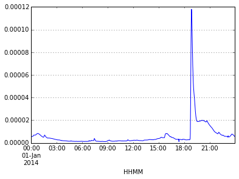

```python
fig = plt.figure()
ax = evelc.data['XRS-B proxy'].plot()
plt.show()
```

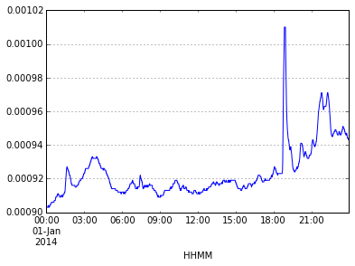

```python
ax = evelc.data['17.1ESP'].plot()
```

```python
evelc.meta
```

```
OrderedDict([('DATA_list', '20140101_EVE_L0CS_DIODES_1m.txt'), ('Created', 'Wed Jan  1 23:59:12 2014 UTC'), ('Origin', 'SDO/EVE Science Processing and Operations Center, LASP/CU'), ('Units', 'W/m^2 for irradiance, dark is counts/(0.25s sample), quadrants are unitless, solar lat & lon are deg'), ('So…
```

```python
from pandas import isnull
evelc.data['17.1ESP'][evelc.data['17.1ESP'] == -1]
```

```
Series([], Name: 17.1ESP, dtype: float64)
```

```python
evelc.data['17.1ESP'][evelc.data['17.1ESP'] == -1] = np.nan
```

```python
evelc.data.replace(-1, np.nan)
```

| HHMM | XRS-B proxy | XRS-A proxy | SEM proxy | 0.1-7ESPquad | 17.1ESP | 25.7ESP | 30.4ESP | 36.6ESP | darkESP | 121.6MEGS-P | darkMEGS-P | q0ESP | q1ESP | q2ESP | q3ESP | CMLat | CMLon | x_cool proxy | oldXRSB proxy |
| --- | --- | --- | --- | --- | --- | --- | --- | --- | --- | --- | --- | --- | --- | --- | --- | --- | --- | --- | --- |
| 2014-01-01 00:00:00 | 0.000006 | 4.030000e-07 | 0.000858 | 0.00196 | 0.000904 | 0.000547 | 0.000958 | NaN | 49.4 | NaN | 39.2 | 0.334 | 0.157 | 0.351 | 0.158 | -28.9 | -0.9 | 2320 | 0.000005 |
| 2014-01-01 00:01:00 | 0.000006 | 4.010000e-07 | 0.000858 | 0.00195 | 0.000904 | 0.000547 | 0.000959 | NaN | 49.4 | NaN | 39.2 | 0.334 | 0.157 | 0.351 | 0.158 | -28.8 | -0.9 | 2320 | 0.000005 |
| 2014-01-01 00:02:00 | 0.000006 | 4.020000e-07 | 0.000857 | 0.00195 | 0.000903 | 0.000547 | 0.000957 | NaN | 49.4 | NaN | 39.2 | 0.334 | 0.157 | 0.350 | 0.158 | -28.7 | -1.2 | 2320 | 0.000005 |
| 2014-01-01 00:03:00 | 0.000006 | 3.990000e-07 | 0.000857 | 0.00195 | 0.000903 | 0.000547 | 0.000956 | NaN | 49.4 | NaN | 39.2 | 0.334 | 0.157 | 0.351 | 0.158 | -28.8 | NaN | 2330 | 0.000005 |
| 2014-01-01 00:04:00 | 0.000006 | 3.960000e-07 | 0.000856 | 0.00194 | 0.000903 | 0.000547 | 0.000955 | NaN | 49.4 | NaN | 39.2 | 0.334 | 0.157 | 0.351 | 0.158 | -28.7 | NaN | 2330 | 0.000005 |
| 2014-01-01 00:05:00 | 0.000006 | 3.950000e-07 | 0.000856 | 0.00194 | 0.000903 | 0.000547 | 0.000955 | NaN | 49.5 | NaN | 39.2 | 0.335 | 0.157 | 0.350 | 0.158 | -28.8 | -1.3 | 2330 | 0.000005 |
| 2014-01-01 00:06:00 | 0.000006 | 3.960000e-07 | 0.000856 | 0.00194 | 0.000903 | 0.000546 | 0.000955 | NaN | 49.5 | NaN | 39.2 | 0.334 | 0.158 | 0.351 | 0.158 | -28.8 | -1.3 | 2330 | 0.000005 |
| 2014-01-01 00:07:00 | 0.000006 | 3.970000e-07 | 0.000856 | 0.00194 | 0.000903 | 0.000546 | 0.000955 | NaN | 49.5 | NaN | 39.2 | 0.334 | 0.158 | 0.350 | 0.158 | -28.7 | -1.3 | 2330 | 0.000005 |
| 2014-01-01 00:08:00 | 0.000006 | 4.000000e-07 | 0.000856 | 0.00194 | 0.000903 | 0.000546 | 0.000956 | NaN | 49.5 | NaN | 39.2 | 0.335 | 0.158 | 0.350 | 0.158 | -28.7 | -1.8 | 2330 | 0.000005 |
| 2014-01-01 00:09:00 | 0.000006 | 4.020000e-07 | 0.000857 | 0.00195 | 0.000904 | 0.000546 | 0.000956 | NaN | 49.5 | NaN | 39.2 | 0.335 | 0.158 | 0.349 | 0.158 | -28.7 | -2.0 | 2330 | 0.000005 |
| 2014-01-01 00:10:00 | 0.000006 | 4.050000e-07 | 0.000857 | 0.00196 | 0.000904 | 0.000546 | 0.000956 | NaN | 49.5 | NaN | 39.2 | 0.335 | 0.159 | 0.349 | 0.158 | -28.6 | -2.1 | 2340 | 0.000005 |
| 2014-01-01 00:11:00 | 0.000006 | 4.110000e-07 | 0.000856 | 0.00197 | 0.000903 | 0.000546 | 0.000956 | NaN | 49.5 | NaN | 39.2 | 0.335 | 0.159 | 0.349 | 0.158 | -28.6 | -2.4 | 2340 | 0.000005 |
| 2014-01-01 00:12:00 | 0.000006 | 4.250000e-07 | 0.000856 | 0.00199 | 0.000903 | 0.000546 | 0.000955 | 0.000445 | 49.5 | NaN | 39.2 | 0.336 | 0.159 | 0.348 | 0.157 | -28.6 | -3.0 | 2340 | 0.000005 |
| 2014-01-01 00:13:00 | 0.000006 | 4.480000e-07 | 0.000855 | 0.00203 | 0.000903 | 0.000546 | 0.000954 | 0.007550 | 49.5 | NaN | 39.3 | 0.338 | 0.160 | 0.345 | 0.156 | -28.6 | -4.7 | 2340 | 0.000006 |
| 2014-01-01 00:14:00 | 0.000006 | 4.730000e-07 | 0.000855 | 0.00208 | 0.000903 | 0.000546 | 0.000954 | 0.013800 | 49.5 | NaN | 39.3 | 0.341 | 0.161 | 0.343 | 0.156 | -28.5 | -6.7 | 2340 | 0.000006 |
| 2014-01-01 00:15:00 | 0.000007 | 4.970000e-07 | 0.000855 | 0.00212 | 0.000904 | 0.000545 | 0.000954 | 0.242000 | 49.5 | NaN | 39.3 | 0.341 | 0.162 | 0.342 | 0.155 | -28.5 | -7.6 | 2340 | 0.000006 |
| 2014-01-01 00:16:00 | 0.000007 | 5.130000e-07 | 0.000855 | 0.00215 | 0.000904 | 0.000545 | 0.000954 | 0.537000 | 49.5 | NaN | 39.2 | 0.342 | 0.163 | 0.340 | 0.155 | -28.3 | -8.3 | 2350 | 0.000006 |
| 2014-01-01 00:17:00 | 0.000007 | 5.190000e-07 | 0.000855 | 0.00217 | 0.000904 | 0.000545 | 0.000954 | 0.597000 | 49.6 | NaN | 39.2 | 0.343 | 0.164 | 0.338 | 0.155 | -28.2 | -9.5 | 2350 | 0.000006 |
| 2014-01-01 00:18:00 | 0.000007 | 5.260000e-07 | 0.000856 | 0.00218 | 0.000904 | 0.000545 | 0.000956 | 0.998000 | 49.6 | NaN | 39.2 | 0.343 | 0.165 | 0.337 | 0.155 | -28.0 | -10.1 | 2350 | 0.000006 |
| 2014-01-01 00:19:00 | 0.000007 | 5.260000e-07 | 0.000857 | 0.00217 | 0.000905 | 0.000545 | 0.000957 | 0.934000 | 49.6 | NaN | 39.3 | 0.343 | 0.165 | 0.336 | 0.155 | -27.9 | -10.3 | 2350 | 0.000006 |
| 2014-01-01 00:20:00 | 0.000007 | 5.240000e-07 | 0.000857 | 0.00217 | 0.000905 | 0.000545 | 0.000956 | 0.870000 | 49.6 | NaN | 39.3 | 0.343 | 0.166 | 0.336 | 0.155 | -27.9 | -10.6 | 2350 | 0.000006 |
| 2014-01-01 00:21:00 | 0.000007 | 5.220000e-07 | 0.000856 | 0.00216 | 0.000905 | 0.000545 | 0.000955 | 0.808000 | 49.6 | NaN | 39.3 | 0.343 | 0.165 | 0.337 | 0.155 | -27.9 | -10.2 | 2350 | 0.000006 |
| 2014-01-01 00:22:00 | 0.000007 | 5.250000e-07 | 0.000855 | 0.00217 | 0.000905 | 0.000545 | 0.000953 | 0.746000 | 49.6 | NaN | 39.3 | 0.343 | 0.165 | 0.337 | 0.155 | -27.9 | -10.2 | 2360 | 0.000006 |
| 2014-01-01 00:23:00 | 0.000007 | 5.210000e-07 | 0.000855 | 0.00217 | 0.000905 | 0.000546 | 0.000953 | 0.687000 | 49.6 | NaN | 39.3 | 0.343 | 0.165 | 0.337 | 0.155 | -27.9 | -10.2 | 2360 | 0.000006 |
| 2014-01-01 00:24:00 | 0.000007 | 5.220000e-07 | 0.000855 | 0.00216 | 0.000906 | 0.000546 | 0.000953 | 0.629000 | 49.6 | NaN | 39.2 | 0.343 | 0.165 | 0.337 | 0.155 | -28.0 | -10.2 | 2360 | 0.000006 |
| 2014-01-01 00:25:00 | 0.000007 | 5.240000e-07 | 0.000856 | 0.00216 | 0.000906 | 0.000547 | 0.000954 | 0.574000 | 49.6 | NaN | 39.2 | 0.344 | 0.165 | 0.336 | 0.155 | -28.0 | -10.5 | 2360 | 0.000006 |
| 2014-01-01 00:26:00 | 0.000007 | 5.280000e-07 | 0.000856 | 0.00217 | 0.000906 | 0.000547 | 0.000954 | 0.520000 | 49.5 | NaN | 39.3 | 0.343 | 0.165 | 0.336 | 0.155 | -27.9 | -10.5 | 2360 | 0.000006 |
| 2014-01-01 00:27:00 | 0.000007 | 5.290000e-07 | 0.000856 | 0.00218 | 0.000906 | 0.000547 | 0.000955 | 0.470000 | 49.5 | NaN | 39.3 | 0.343 | 0.165 | 0.337 | 0.155 | -28.0 | -10.2 | 2370 | 0.000006 |
| 2014-01-01 00:28:00 | 0.000007 | 5.300000e-07 | 0.000856 | 0.00218 | 0.000906 | 0.000547 | 0.000955 | 0.421000 | 49.5 | NaN | 39.3 | 0.343 | 0.165 | 0.337 | 0.155 | -28.0 | -10.3 | 2370 | 0.000006 |
| 2014-01-01 00:29:00 | 0.000007 | 5.340000e-07 | 0.000856 | 0.00219 | 0.000906 | 0.000548 | 0.000954 | 0.376000 | 49.5 | NaN | 39.3 | 0.343 | 0.165 | 0.338 | 0.154 | -28.1 | -10.2 | 2370 | 0.000006 |
| ... | ... | ... | ... | ... | ... | ... | ... | ... | ... | ... | ... | ... | ... | ... | ... | ... | ... | ... | ... |
| 2014-01-01 23:30:00 | 0.000006 | 5.700000e-07 | 0.000893 | 0.00224 | 0.000951 | 0.000579 | 0.000991 | NaN | 49.6 | NaN | 39.5 | 0.353 | 0.180 | 0.314 | 0.152 | -25.9 | -24.6 | 2830 | 0.000007 |
| 2014-01-01 23:31:00 | 0.000007 | 5.870000e-07 | 0.000893 | 0.00227 | 0.000951 | 0.000579 | 0.000991 | NaN | 49.6 | NaN | 39.5 | 0.354 | 0.181 | 0.312 | 0.152 | -25.8 | -25.5 | 2830 | 0.000007 |
| 2014-01-01 23:32:00 | 0.000007 | 6.110000e-07 | 0.000893 | 0.00231 | 0.000951 | 0.000579 | 0.000992 | NaN | 49.6 | NaN | 39.5 | 0.355 | 0.182 | 0.311 | 0.152 | -25.7 | -26.3 | 2830 | 0.000007 |
| 2014-01-01 23:33:00 | 0.000007 | 6.300000e-07 | 0.000894 | 0.00234 | 0.000950 | 0.000578 | 0.000993 | NaN | 49.6 | NaN | 39.5 | 0.356 | 0.182 | 0.310 | 0.151 | -25.7 | -27.1 | 2830 | 0.000007 |
| 2014-01-01 23:34:00 | 0.000007 | 6.600000e-07 | 0.000894 | 0.00238 | 0.000950 | 0.000578 | 0.000993 | NaN | 49.6 | NaN | 39.5 | 0.358 | 0.183 | 0.309 | 0.151 | -25.7 | -28.3 | 2830 | 0.000007 |
| 2014-01-01 23:35:00 | 0.000007 | 6.830000e-07 | 0.000894 | 0.00242 | 0.000950 | 0.000578 | 0.000994 | NaN | 49.7 | NaN | 39.5 | 0.359 | 0.183 | 0.307 | 0.151 | -25.6 | -29.2 | 2830 | 0.000007 |
| 2014-01-01 23:36:00 | 0.000008 | 7.000000e-07 | 0.000894 | 0.00245 | 0.000950 | 0.000578 | 0.000994 | 0.020300 | 49.6 | NaN | 39.6 | 0.359 | 0.184 | 0.306 | 0.150 | -25.5 | -30.1 | 2830 | 0.000008 |
| 2014-01-01 23:37:00 | 0.000008 | 7.120000e-07 | 0.000893 | 0.00247 | 0.000949 | 0.000578 | 0.000993 | 0.430000 | 49.6 | NaN | 39.6 | 0.359 | 0.185 | 0.306 | 0.150 | -25.4 | -30.6 | 2830 | 0.000008 |
| 2014-01-01 23:38:00 | 0.000008 | 7.100000e-07 | 0.000893 | 0.00247 | 0.000949 | 0.000578 | 0.000992 | 0.501000 | 49.6 | NaN | 39.6 | 0.359 | 0.186 | 0.304 | 0.150 | -25.2 | -31.3 | 2830 | 0.000008 |
| 2014-01-01 23:39:00 | 0.000008 | 7.080000e-07 | 0.000892 | 0.00246 | 0.000948 | 0.000578 | 0.000991 | 0.480000 | 49.6 | NaN | 39.6 | 0.360 | 0.186 | 0.304 | 0.150 | -25.2 | -31.4 | 2830 | 0.000008 |
| 2014-01-01 23:40:00 | 0.000008 | 7.060000e-07 | 0.000892 | 0.00246 | 0.000948 | 0.000578 | 0.000991 | 0.457000 | 49.7 | NaN | 39.6 | 0.359 | 0.187 | 0.304 | 0.150 | -25.0 | -31.7 | 2830 | 0.000008 |
| 2014-01-01 23:41:00 | 0.000008 | 7.030000e-07 | 0.000891 | 0.00245 | 0.000947 | 0.000578 | 0.000990 | 0.434000 | 49.6 | NaN | 39.6 | 0.360 | 0.187 | 0.303 | 0.150 | -25.1 | -31.9 | 2830 | 0.000008 |
| 2014-01-01 23:42:00 | 0.000008 | 6.930000e-07 | 0.000890 | 0.00244 | 0.000947 | 0.000577 | 0.000989 | 0.410000 | 49.6 | NaN | 39.6 | 0.359 | 0.187 | 0.304 | 0.150 | -25.0 | -31.7 | 2830 | 0.000007 |
| 2014-01-01 23:43:00 | 0.000007 | 6.840000e-07 | 0.000890 | 0.00242 | 0.000947 | 0.000577 | 0.000988 | 0.386000 | 49.6 | NaN | 39.6 | 0.359 | 0.187 | 0.304 | 0.151 | -25.0 | -31.5 | 2830 | 0.000007 |
| 2014-01-01 23:44:00 | 0.000007 | 6.750000e-07 | 0.000891 | 0.00241 | 0.000946 | 0.000577 | 0.000989 | 0.452000 | 49.6 | NaN | 39.6 | 0.360 | 0.186 | 0.304 | 0.151 | -25.1 | -31.6 | 2830 | 0.000007 |
| 2014-01-01 23:45:00 | 0.000007 | 6.590000e-07 | 0.000890 | 0.00239 | 0.000946 | 0.000577 | 0.000988 | 1.100000 | 49.6 | NaN | 39.6 | 0.359 | 0.186 | 0.304 | 0.151 | -25.0 | -31.2 | 2830 | 0.000007 |
| 2014-01-01 23:46:00 | 0.000007 | 6.490000e-07 | 0.000890 | 0.00237 | 0.000946 | 0.000577 | 0.000988 | 1.070000 | 49.6 | NaN | 39.6 | 0.358 | 0.186 | 0.304 | 0.151 | -25.0 | -30.7 | 2830 | 0.000007 |
| 2014-01-01 23:47:00 | 0.000007 | 6.340000e-07 | 0.000889 | 0.00235 | 0.000946 | 0.000577 | 0.000988 | 0.996000 | 49.6 | NaN | 39.6 | 0.358 | 0.187 | 0.304 | 0.151 | -24.9 | -30.7 | 2830 | 0.000007 |
| 2014-01-01 23:48:00 | 0.000007 | 6.190000e-07 | 0.000890 | 0.00233 | 0.000947 | 0.000577 | 0.000988 | 0.922000 | 49.6 | NaN | 39.6 | 0.358 | 0.187 | 0.304 | 0.151 | -24.9 | -30.6 | 2830 | 0.000007 |
| 2014-01-01 23:49:00 | 0.000007 | 6.040000e-07 | 0.000889 | 0.00230 | 0.000946 | 0.000577 | 0.000988 | 0.850000 | 49.6 | NaN | 39.7 | 0.357 | 0.186 | 0.305 | 0.151 | -25.0 | -30.0 | 2830 | 0.000007 |
| 2014-01-01 23:50:00 | 0.000007 | 5.870000e-07 | 0.000889 | 0.00227 | 0.000946 | 0.000577 | 0.000988 | 0.781000 | 49.6 | NaN | 39.7 | 0.357 | 0.187 | 0.305 | 0.152 | -24.8 | -29.9 | 2830 | 0.000007 |
| 2014-01-01 23:51:00 | 0.000006 | 5.700000e-07 | 0.000888 | 0.00224 | 0.000945 | 0.000576 | 0.000987 | 0.713000 | 49.6 | NaN | 39.7 | 0.357 | 0.186 | 0.305 | 0.152 | -24.9 | -29.6 | 2830 | 0.000007 |
| 2014-01-01 23:52:00 | 0.000006 | 5.550000e-07 | 0.000887 | 0.00222 | 0.000944 | 0.000576 | 0.000985 | 0.783000 | 49.6 | NaN | 39.7 | 0.357 | 0.186 | 0.306 | 0.152 | -25.0 | -29.4 | 2830 | 0.000006 |
| 2014-01-01 23:53:00 | 0.000006 | 5.380000e-07 | 0.000886 | 0.00219 | 0.000944 | 0.000575 | 0.000983 | 1.020000 | 49.6 | NaN | 39.7 | 0.356 | 0.185 | 0.307 | 0.152 | -25.2 | -28.8 | 2830 | 0.000006 |
| 2014-01-01 23:54:00 | 0.000006 | 5.260000e-07 | 0.000885 | 0.00217 | 0.000944 | 0.000576 | 0.000982 | 1.020000 | 49.6 | NaN | 39.7 | 0.355 | 0.185 | 0.307 | 0.152 | -25.1 | -28.4 | 2830 | 0.000006 |
| 2014-01-01 23:55:00 | 0.000006 | 5.140000e-07 | 0.000885 | 0.00215 | 0.000944 | 0.000576 | 0.000981 | 1.060000 | 49.7 | NaN | 39.7 | 0.355 | 0.185 | 0.308 | 0.152 | -25.0 | -28.0 | 2830 | 0.000006 |
| 2014-01-01 23:56:00 | 0.000006 | 5.010000e-07 | 0.000884 | 0.00213 | 0.000944 | 0.000577 | 0.000980 | 1.100000 | 49.6 | NaN | 39.6 | 0.355 | 0.185 | 0.308 | 0.152 | -25.1 | -27.9 | 2830 | 0.000006 |
| 2014-01-01 23:57:00 | 0.000006 | 4.870000e-07 | 0.000885 | 0.00211 | 0.000943 | 0.000577 | 0.000982 | 1.000000 | 49.7 | NaN | 39.7 | 0.354 | 0.185 | 0.308 | 0.153 | -25.0 | -27.4 | 2830 | 0.000006 |
| 2014-01-01 23:58:00 | 0.000006 | 4.750000e-07 | 0.000887 | 0.00208 | 0.000943 | 0.000577 | 0.000984 | 0.905000 | 49.6 | NaN | 39.7 | 0.354 | 0.185 | 0.309 | 0.153 | -25.1 | -27.0 | 2830 | 0.000006 |
| 2014-01-01 23:59:00 | 0.000006 | 4.700000e-07 | 0.000887 | 0.00207 | 0.000943 | 0.000576 | 0.000985 | 0.852000 | 49.6 | NaN | 39.7 | 0.354 | 0.185 | 0.309 | 0.153 | -25.1 | -27.0 | 2830 | 0.000006 |

1440 rows × 19 columns

```python
evelc.data['17.1ESP'][evelc.data['17.1ESP'] == -1]
```

```
Series([], Name: 17.1ESP, dtype: float64)
```

```python
import pandas as pd
pd.__version__
```

```
'0.16.1'
```

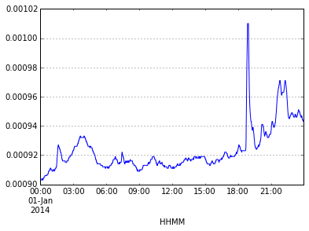

```python
ax = evelc.data['17.1ESP'].plot()
```

## Solar Constants

```python
from sunpy.sun import constants as sun
```

```python
sun.mass
```

$1.9891 \times 10^{30} \; \mathrm{kg}$

```python
type(sun.mass)
```

```
astropy.constants.constant.Constant
```

```python
print(sun.mass)
```

```
  Name   = Solar mass
  Value  = 1.9891e+30
  Error  = 5e+25
  Units  = kg
  Reference = Allen's Astrophysical Quantities 4th Ed.
```

```python
(sun.mass/sun.volume).cgs
```

$1.4085115 \; \mathrm{\frac{g}{cm^{3}}}$

```python
sun.find('age')
```

```
['age', 'average angular size', 'average density', 'average intensity']
```

```python
sun.value('age'), sun.unit('age')
```

```
(4600000000.0, Unit("yr"))
```

## Searching the VSO

```python
from sunpy.net import vso
client = vso.VSOClient()
tstart, tend = '2011/6/7 05:30', '2011/6/7 6:30'
```

```python
lasco_query = client.query(vso.attrs.Time(tstart, tend), vso.attrs.Instrument('lasco'))
```

```python
lasco_query.num_records()
```

```
8
```

```python
lasco_query.show()
```

```
   Start Time [1]       End Time [1]    Source Instrument  Type
------------------- ------------------- ------ ---------- ------
2011-06-07 05:35:23 2011-06-07 05:35:48   SOHO      LASCO CORONA
2011-06-07 05:50:13 2011-06-07 05:50:38   SOHO      LASCO CORONA
2011-06-07 06:04:58 2011-06-07 06:05:23   SOHO      LASCO CORONA
2011-06-07 06:19:43 2011-06-07 06:20:08   SOHO      LASCO CORONA
2011-06-07 05:43:09 2011-06-07 05:43:29   SOHO      LASCO CORONA
2011-06-07 05:57:59 2011-06-07 05:58:18   SOHO      LASCO CORONA
2011-06-07 06:12:45 2011-06-07 06:13:04   SOHO      LASCO CORONA
2011-06-07 06:27:29 2011-06-07 06:27:48   SOHO      LASCO CORONA
```

now download the data

```python
pathformat = '/Users/schriste/sunpy/data/{file}.fits'
results = client.get(lasco_query, path = pathformat)
```

```python
instrument_condition = ( vso.attrs.Instrument('lasco') | vso.attrs.Detector('cor1') )
coronagraphs = client.query(vso.attrs.Time(tstart, tend), instrument_condition)
coronagraphs.num_records()
```

```
117
```

```python
coronagraphs.show()
```

```
   Start Time [1]       End Time [1]     Source  Instrument  Type
------------------- ------------------- -------- ---------- ------
2011-06-07 05:35:23 2011-06-07 05:35:48     SOHO      LASCO CORONA
2011-06-07 05:50:13 2011-06-07 05:50:38     SOHO      LASCO CORONA
2011-06-07 06:04:58 2011-06-07 06:05:23     SOHO      LASCO CORONA
2011-06-07 06:19:43 2011-06-07 06:20:08     SOHO      LASCO CORONA
2011-06-07 05:43:09 2011-06-07 05:43:29     SOHO      LASCO CORONA
2011-06-07 05:57:59 2011-06-07 05:58:18     SOHO      LASCO CORONA
2011-06-07 06:12:45 2011-06-07 06:13:04     SOHO      LASCO CORONA
2011-06-07 06:27:29 2011-06-07 06:27:48     SOHO      LASCO CORONA
2011-06-07 05:30:00 2011-06-07 05:30:01 STEREO_A     SECCHI CORONA
2011-06-07 05:30:09 2011-06-07 05:30:10 STEREO_A     SECCHI CORONA
                ...                 ...      ...        ...    ...
2011-06-07 06:23:13 2011-06-07 06:23:15 STEREO_B     SECCHI CORONA
2011-06-07 06:25:00 2011-06-07 06:25:01 STEREO_A     SECCHI CORONA
2011-06-07 06:25:09 2011-06-07 06:25:10 STEREO_A     SECCHI CORONA
2011-06-07 06:25:18 2011-06-07 06:25:19 STEREO_A     SECCHI CORONA
2011-06-07 06:25:25 2011-06-07 06:25:27 STEREO_B     SECCHI CORONA
2011-06-07 06:25:34 2011-06-07 06:25:36 STEREO_B     SECCHI CORONA
2011-06-07 06:25:43 2011-06-07 06:25:45 STEREO_B     SECCHI CORONA
2011-06-07 06:27:55 2011-06-07 06:27:57 STEREO_B     SECCHI CORONA
2011-06-07 06:28:04 2011-06-07 06:28:06 STEREO_B     SECCHI CORONA
2011-06-07 06:28:13 2011-06-07 06:28:15 STEREO_B     SECCHI CORONA
2011-06-07 06:30:00 2011-06-07 06:30:01 STEREO_A     SECCHI CORONA
Length = 117 rows
```

## Searching for events in the HEK

```python
from sunpy.net import hek
client = hek.HEKClient()
tstart, tend = '2011/08/09 00:00:00', '2011/08/10 00:00:00'
result = client.query(hek.attrs.Time(tstart,tend), hek.attrs.EventType('FL')) # ’FL’ indicates flare
len(result)
```

```
52
```

```python
result[0]
```

```
{u'SOL_standard': u'SOL2011-08-08T01:30:04L247C075',
 u'active': u'true',
 u'ar_compactnesscls': u'',
 u'ar_mcintoshcls': u'',
 u'ar_mtwilsoncls': u'',
 u'ar_noaaclass': u'',
 u'ar_noaanum': None,
 u'ar_numspots': None,
 u'ar_penumbracls': u'',
 u'ar_polarity': None,
 u'ar_zurichcls': u'',
 u'area_atdiskcenter': None,
 u'area_atdiskcenteruncert': None,
 u'area_raw': None,
 u'area_uncert': None,
 u'area_unit': u'',
 u'bound_ccnsteps': None,
 u'bound_ccstartc1': None,
 u'bound_ccstartc2': None,
 u'bound_chaincode': u'',
 u'boundbox_c1ll': -470,
 u'boundbox_c1ur': 573,
 u'boundbox_c2ll': -174,
 u'boundbox_c2ur': 476,
 u'chaincodetype': u'',
 u'comment_count': u'0',
 u'concept': u'Flare ',
 u'event_avg_rating': 0.8,
 u'event_c1error': 521.5,
 u'event_c2error': 324.9,
 u'event_clippedspatial': u'',
 u'event_clippedtemporal': u'',
 u'event_coord1': 51,
 u'event_coord2': 151,
 u'event_coord3': None,
 u'event_coordsys': u'UTC-HPC-TOPO',
 u'event_coordunit': u'arcsec',
 u'event_description': u'Small flare in the lower pat of the AR. Few instants before, a coronal shock wave appears from the right part of the image.',
 u'event_endtime': u'2011-08-10T00:00:04',
 u'event_expires': u'',
```

[output cut: 88 more lines]

```
 u'refs': [{u'ref_name': u'FL:  HER Entry',
   u'ref_type': u'ivorn',
   u'ref_url': u'ivo://helio-informatics.org/FL6173_AlbertoSainzDalda_20110811_172601'},
  {u'ref_name': u'Movie',
   u'ref_type': u'movie',
   u'ref_url': u'http://sdowww.lmsal.com/sdomedia/h264/2011/08/08/AVC_AlbertoSainzDalda_20110808T013004-20110810T000004_SDO_211-6173_300.0_20110811_172601.mov'},
  {u'ref_name': u'Event_MapURL', u'ref_type': u'unknown', u'ref_url': u''},
  {u'ref_name': u'FRM_URL', u'ref_type': u'unknown', u'ref_url': u'n/a'}],
 u'refs_orig': u'',
 u'revision': u'1',
 u'skel_chaincode': u'',
 u'skel_curvature': None,
 u'skel_nsteps': None,
 u'skel_startc1': None,
 u'skel_startc2': None}
```

Filter the results of the previous result to return only those events that have the FRM ‘SSW Latest Events’

```python
result = client.query(hek.attrs.Time(tstart, tend), hek.attrs.EventType('FL'), hek.attrs.FRM.Name=='SSW Latest Events')
```

```python
len(result)
```

```
9
```

The following returns flares west of 50 arcseconds or those that have a peak flux above 1000.0 (the units of the flux are FRM- dependent and are described at the HEK website)

```python
result = client.query(hek.attrs.Time(tstart, tend), hek.attrs.EventType('FL'), (hek.attrs.Event.Coord1>50) or (hek.attrs.FL.PeakFlux>1000.0))
```

```python
len(result)
```

```
48
```

## More References

- [Python for Data Analysis](http://shop.oreilly.com/product/0636920023784.do) by Wes McKinney is great
- [Lectures on scientific computing with Python](http://jrjohansson.github.io) Great lectures on scientific computing in Python